# Trabalho ASN Regressão Linear

```r
#Analisando os outliers
Bodyfat_Chest= Bodyfat[order(Bodyfat$Chest),]
tail(Bodyfat_Chest ,4)
```

```
## # A tibble: 4 × 14
##   bodyfat   Age Weight Height  Neck Chest Abdomen   Hip Thigh  Knee Ankle Biceps
##     <dbl> <dbl>  <dbl>  <dbl> <dbl> <dbl>   <dbl> <dbl> <dbl> <dbl> <dbl>  <dbl>
## 1    26      54   104.   1.81  42.5  120.    110.  106.  64.2  42.7  27     38.4
## 2    34.8    44   101.   1.74  40.9  122.    114.  107.  63.5  40.3  21.8   34.8
## 3    34.5    45   119.   1.72  43.2  128.    126.  126.  72.5  39.6  26.6   36.4
## 4    35.2    46   165.   1.81  51.2  136.    148.  148.  87.3  49.1  29.6   45
## # … with 2 more variables: Forearm <dbl>, Wrist <dbl>
```

```r
# Realiza o teste
testeShapiro_Chest<- shapiro.test(Bodyfat$Chest)

# Exibe teste
testeShapiro_Chest
```

```
##
##  Shapiro-Wilk normality test
##
## data:  Bodyfat$Chest
## W = 0.96863, p-value = 2.612e-05
```

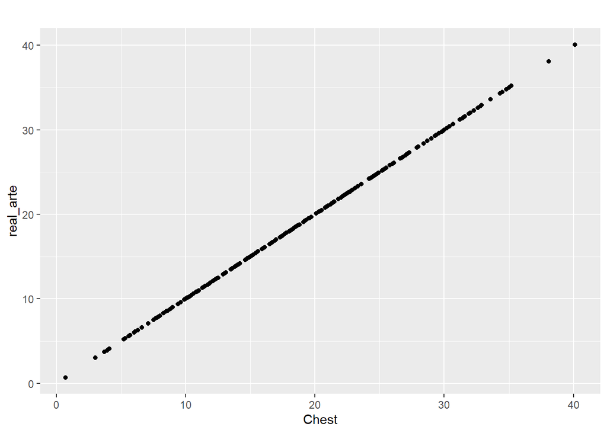

```r
meus_desenhos <- Bodyfat %>% mutate(chute_media_Chest = mean(Bodyfat$bodyfat),chute_modelo_Chest = reg_simples_Chest$fitted.values)

arte <- ggplot()
arte <- arte + geom_point(data=meus_desenhos, aes(x=bodyfat, y=bodyfat), color = "black" ) +
  labs(title = "",
       x = "Chest",
       y = "real_arte",
       color = "green")
arte
```

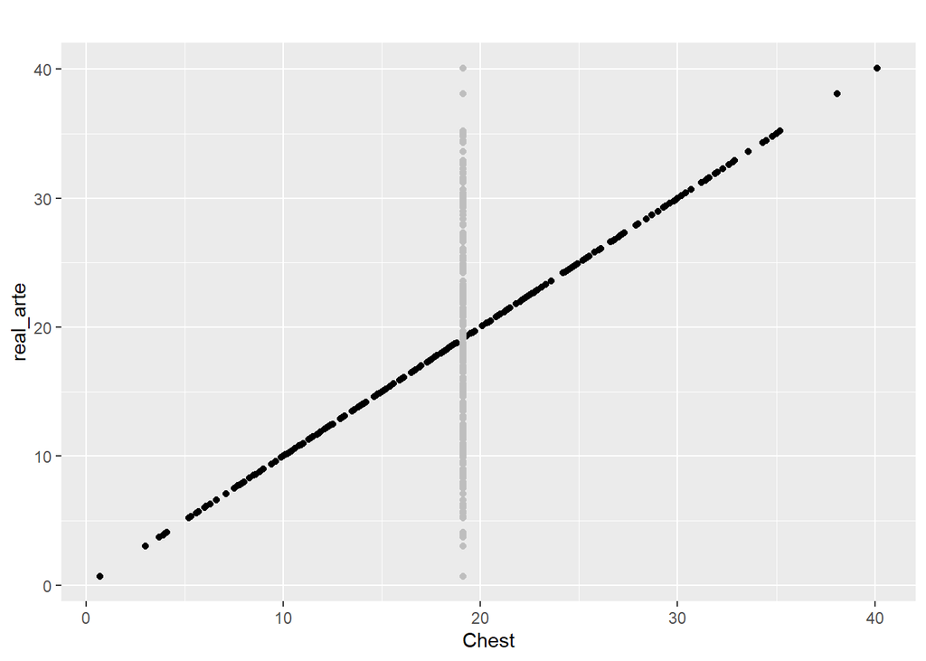

```r
arte <- arte + geom_point(data=meus_desenhos, aes(x=chute_media_Chest, y=bodyfat), color = "gray" )
arte
```

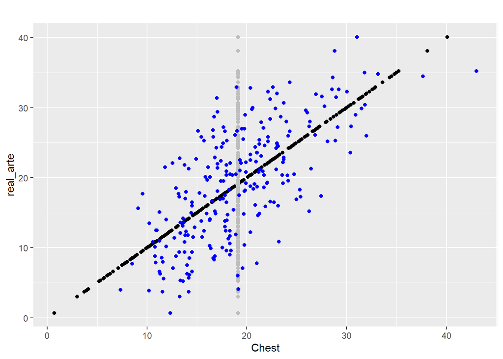

```r
arte <- arte + geom_point(data=meus_desenhos, aes(x=chute_modelo_Chest, y=bodyfat), color = "blue" )
arte
```

#### Abdomen:

**Analisando os dados descritivos.**

```r
summary(Bodyfat$Abdomen)
```

```
##    Min. 1st Qu.  Median    Mean 3rd Qu.    Max.
##   70.40   84.75   90.95   92.53   99.20  148.10
```

**Desvio Padrão.**

```r
sd(Bodyfat$Abdomen)
```

```
## [1] 10.56169
```

**Histograma**

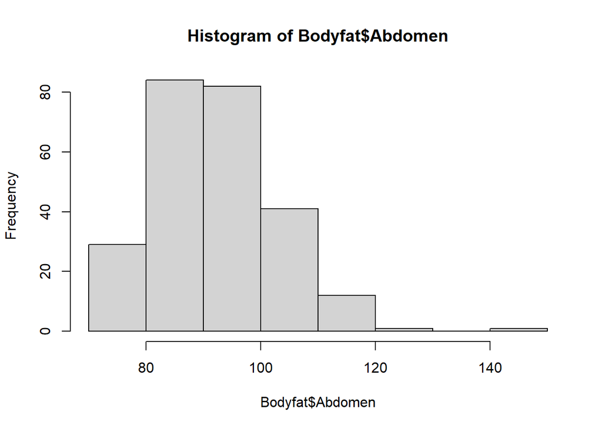

```r
hist(Bodyfat$Abdomen)
```

**BoxPlot**

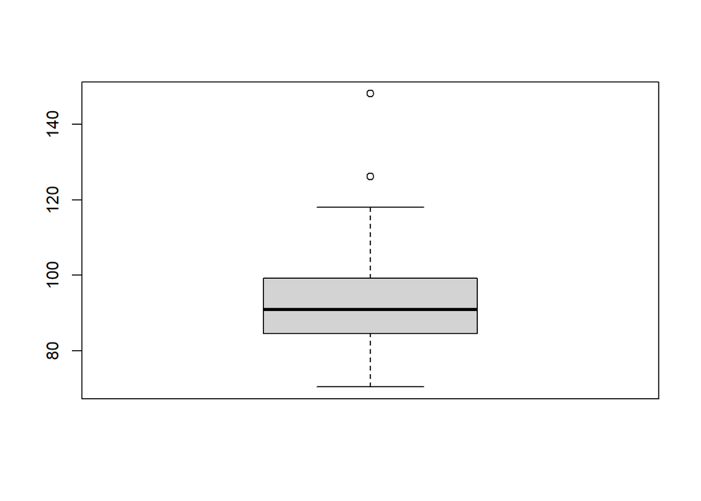

```r
boxplot(Bodyfat$Abdomen)
```

**Analisa os outliers**

```r
Bodyfat_abd = Bodyfat[order(Bodyfat$Abdomen),]

tail(Bodyfat_abd ,3)
```

```
## # A tibble: 3 × 14
##   bodyfat   Age Weight Height  Neck Chest Abdomen   Hip Thigh  Knee Ankle Biceps
##     <dbl> <dbl>  <dbl>  <dbl> <dbl> <dbl>   <dbl> <dbl> <dbl> <dbl> <dbl>  <dbl>
## 1    35      65   102.   1.71  38.8  120.    118   114.  61.3  42.1  23.4   34.9
## 2    34.5    45   119.   1.72  43.2  128.    126.  126.  72.5  39.6  26.6   36.4
## 3    35.2    46   165.   1.81  51.2  136.    148.  148.  87.3  49.1  29.6   45
## # … with 2 more variables: Forearm <dbl>, Wrist <dbl>
```

Identificando se a variável segue uma distribuição normal

Teste de Shapiro-Wilk

Vamos utilizar um vetor que irá conter os dados.

Hipóteses:

H0: Os dados seguem a distribuição normal H1: Os dados não seguem a distribuição normal

Para a realização desse teste é necessário a instalação do pacote nortest

```r
# Carrega pacote
#library(nortest)

# Realiza o teste
testeShapiro <- shapiro.test(Bodyfat$Abdomen)

# Exibe teste
testeShapiro
```

```
##
##  Shapiro-Wilk normality test
##
## data:  Bodyfat$Abdomen
## W = 0.96303, p-value = 4.769e-06
```

```r
filter(Bodyfat, is.na(Abdomen))
```

```
## # A tibble: 0 × 14
## # … with 14 variables: bodyfat <dbl>, Age <dbl>, Weight <dbl>, Height <dbl>,
## #   Neck <dbl>, Chest <dbl>, Abdomen <dbl>, Hip <dbl>, Thigh <dbl>, Knee <dbl>,
## #   Ankle <dbl>, Biceps <dbl>, Forearm <dbl>, Wrist <dbl>
```

*Observações Abdomen*:

Percebe-se que o desvio padrão dos dados é relativamente baixo, comparando com os valores disponíveis.

Analisei os maiores valores e menores valores e percebi que não existem valores “incorretos ou inviáveis”

A distribuição não é normal e percebi a presença de outliers nos grandes valores.

Variável dependente Hip(Quadril):

Analisando os dados estatisticos.

```r
summary(Bodyfat$Hip)
```

```
##    Min. 1st Qu.  Median    Mean 3rd Qu.    Max.
##   85.30   95.53   99.30   99.91  103.42  147.70
```

```r
sd(Bodyfat$Hip)
```

```
## [1] 7.083495
```

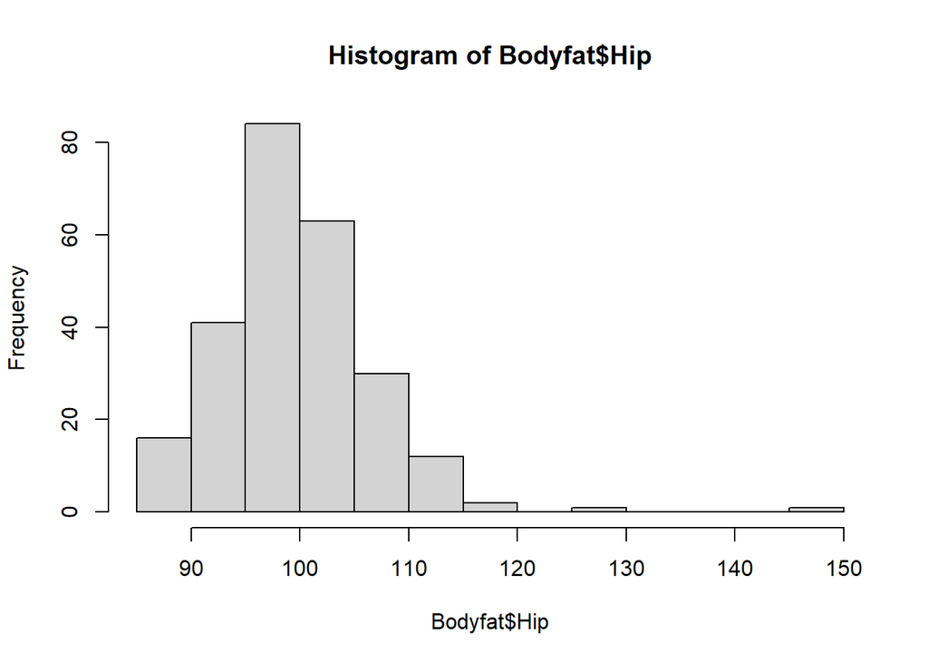

```r
hist(Bodyfat$Hip)
```

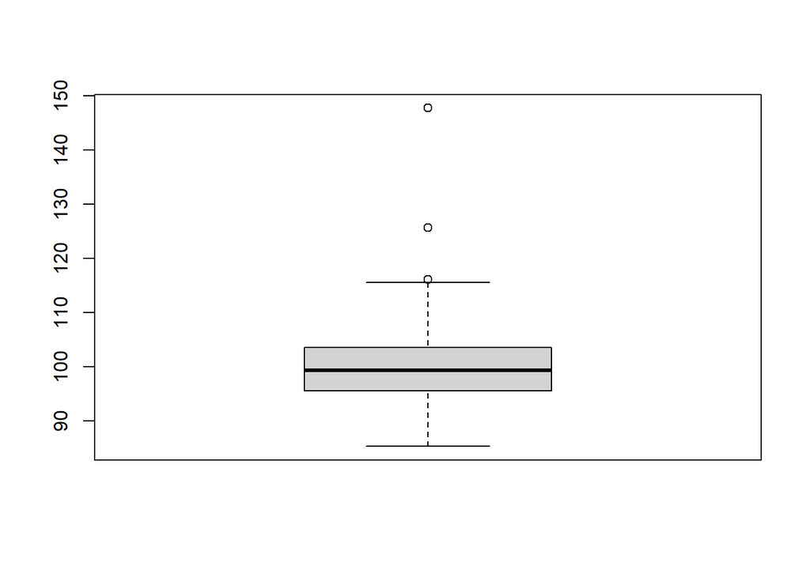

```r
boxplot(Bodyfat$Hip)
```

```r
#Analisando os outliers
Bodyfat_hip = Bodyfat[order(Bodyfat$Hip),]
tail(Bodyfat_hip ,3)
```

```
## # A tibble: 3 × 14
##   bodyfat   Age Weight Height  Neck Chest Abdomen   Hip Thigh  Knee Ankle Biceps
##     <dbl> <dbl>  <dbl>  <dbl> <dbl> <dbl>   <dbl> <dbl> <dbl> <dbl> <dbl>  <dbl>
## 1    32.3    41   112.   1.84  42.1  117     116.  116.  71.2  43.3  26.3   37.3
## 2    34.5    45   119.   1.72  43.2  128.    126.  126.  72.5  39.6  26.6   36.4
## 3    35.2    46   165.   1.81  51.2  136.    148.  148.  87.3  49.1  29.6   45
## # … with 2 more variables: Forearm <dbl>, Wrist <dbl>
```

```r
# Carrega pacote
#library(nortest)

# Realiza o teste
testeShapiro <- shapiro.test(Bodyfat$Hip)

# Exibe teste
testeShapiro
```

```
##
##  Shapiro-Wilk normality test
##
## data:  Bodyfat$Hip
## W = 0.91682, p-value = 1.361e-10
```

```r
filter(Bodyfat, is.na(Hip))
```

```
## # A tibble: 0 × 14
## # … with 14 variables: bodyfat <dbl>, Age <dbl>, Weight <dbl>, Height <dbl>,
## #   Neck <dbl>, Chest <dbl>, Abdomen <dbl>, Hip <dbl>, Thigh <dbl>, Knee <dbl>,
## #   Ankle <dbl>, Biceps <dbl>, Forearm <dbl>, Wrist <dbl>
```

*Observações Hip(Quadril)*

Observa-se um baixo desvio padrão, mas com algumas ocorrencias de outliers.

A distribuição não é normal e e percebi que não existem valores “incorretos ou inviáveis”.

Ao pesquisar sobre o Quadril, encontrei no site abaixo uma relação entre Abdomen e Quadril. Talvez seja interessante ter uma nova variável abrindo novas possibilidades de melhoria do modelo.

https://vitat.com.br/relacao-cintura-quadril/

Variável dependente Thigh(Coxa):

Analisando os dados estatisticos.

```r
summary(Bodyfat$Thigh)
```

```
##    Min. 1st Qu.  Median    Mean 3rd Qu.    Max.
##   49.30   56.02   59.00   59.44   62.30   87.30
```

```r
sd(Bodyfat$Thigh)
```

```
## [1] 5.210112
```

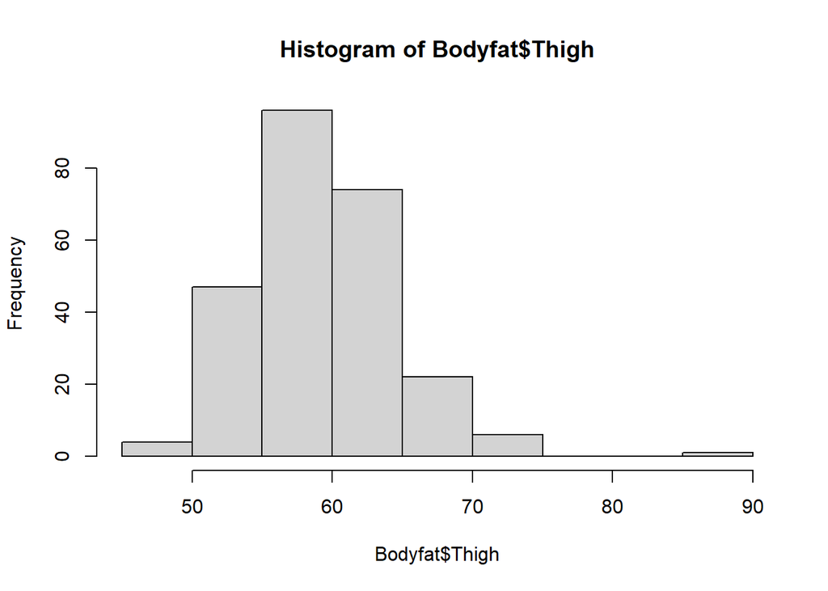

```r
hist(Bodyfat$Thigh)
```

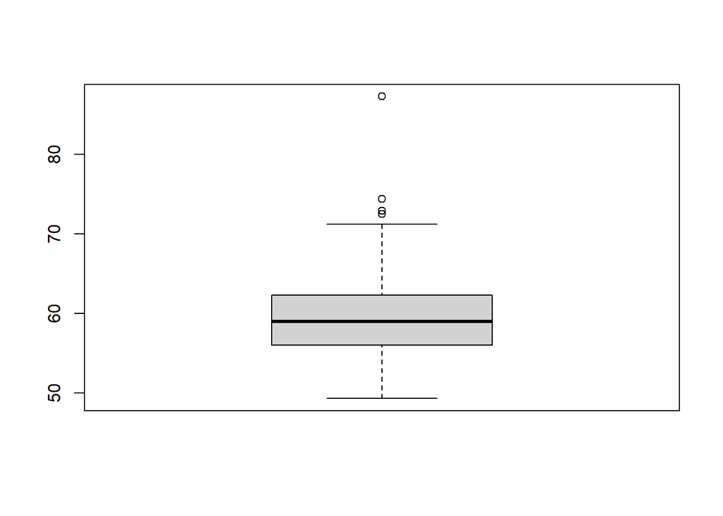

```r
boxplot(Bodyfat$Thigh)
```

```r
#Analisando os outliers
Bodyfat_Thigh = Bodyfat[order(Bodyfat$Thigh),]
tail(Bodyfat_Thigh ,4)
```

```
## # A tibble: 4 × 14
##   bodyfat   Age Weight Height  Neck Chest Abdomen   Hip Thigh  Knee Ankle Biceps
##     <dbl> <dbl>  <dbl>  <dbl> <dbl> <dbl>   <dbl> <dbl> <dbl> <dbl> <dbl>  <dbl>
## 1    34.5    45   119.   1.72  43.2  128.    126.  126.  72.5  39.6  26.6   36.4
## 2    19.6    26   110.   1.86  41.8  108.    103.  114.  72.9  43.5  25.1   38.5
## 3    34.3    35   104.   1.74  40.4  115.    116.  112.  74.4  40.6  24     36.1
## 4    35.2    46   165.   1.81  51.2  136.    148.  148.  87.3  49.1  29.6   45
## # … with 2 more variables: Forearm <dbl>, Wrist <dbl>
```

```r
# Carrega pacote
#library(nortest)

# Realiza o teste
testeShapiro <- shapiro.test(Bodyfat$Thigh)

# Exibe teste
testeShapiro
```

```
##
##  Shapiro-Wilk normality test
##
## data:  Bodyfat$Thigh
## W = 0.96149, p-value = 3.064e-06
```

```r
filter(Bodyfat, is.na(Thigh))
```

```
## # A tibble: 0 × 14
## # … with 14 variables: bodyfat <dbl>, Age <dbl>, Weight <dbl>, Height <dbl>,
## #   Neck <dbl>, Chest <dbl>, Abdomen <dbl>, Hip <dbl>, Thigh <dbl>, Knee <dbl>,
## #   Ankle <dbl>, Biceps <dbl>, Forearm <dbl>, Wrist <dbl>
```

*Observações Thigh(Coxa)*

Observa-se um baixo desvio padrão, mas com ocorrencias de outliers um pouco maior do que as anteriores.

A distribuição não é normal e e percebi que não existem valores “incorretos ou inviáveis”.

Não encontrei nenhuma particularidade sobre a coxa em relação as demais partes do corpo

*Variável dependente Knee(Joelho):*

Analisando os dados estatisticos.

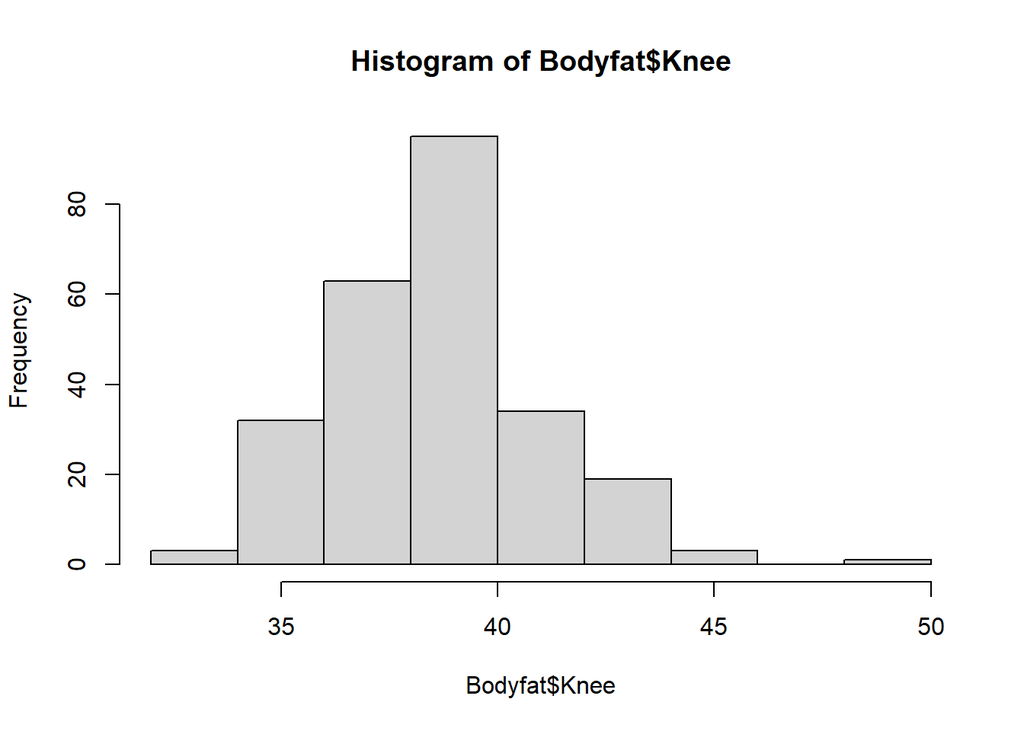

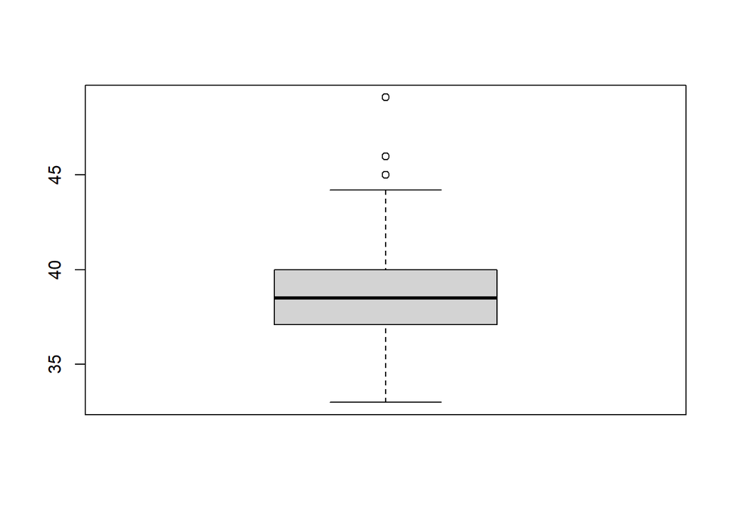